# Tech Migration to the Seattle Metro Area

And Across the United States

Gavin Morrow

Mar 11, 2026

## Objectives

- Understand the difference in migration for tech jobs in relation to overall migration patterns
- See how this correlates with different years in this century with different economic times
- Attempt to make predictions about the future of tech migration in the Seattle Metro Area

## Methods and Data

- Data: ACS 2024, 2021, 2016, 2006 years chosen for different times + State and County shapefiles
- Define and filter for someone migrating for a tech job
- Create Migration Efficiency graphs of County and State for tech migration
- Compare Migration trends between chosen years

```r
library(ipumsr)
library(tidyverse)
library(gt)
library(scales)
library(sf)

# wkdir is the root of your project directory
wkdir <- here::here()

# set directories for where you store data and save plots relative to project root
dataDir <- file.path(wkdir, "data")  #read data file dir
plotsDir <- file.path(wkdir, "plots")  #save plot files dir

options(scipen=99, digits=5)

# create plots directory if it does not exist
ifelse(!dir.exists(file.path(wkdir, "plots")), dir.create(file.path(wkdir, "plots")), FALSE)


options(scipen=99, digits = 5)
```

```r
if (!require("ipumsr")) stop("Reading IPUMS data into R requires the ipumsr package. It can be installed using the following command: install.packages('ipumsr')")

dataSet <- "usa_00007.xml"  # name of YOUR 2023 xml file

ddi <- read_ipums_ddi(file.path(dataDir,dataSet)) # ACS 2023
data <- read_ipums_micro(ddi)

# extract variable names the traditional way (useful reference)
varname <- as.data.frame(colnames(data))

# create webpage of variable names, labels and values, save it as dataSet.html in the data directory
# useful for reference
ipums_view(ddi, launch = FALSE, out_file=file.path(wkdir, "data", paste0(dataSet,".html" )))

# add a state name variable to data
# first, create a dataframe with statefips codes (as val) and statenames (as lbl) from variable STATEIP
STATES <- ipums_val_labels(ddi, STATEFIP)

# then, join STATES to data (using: STATEFIP=val) and rename new variable lbl as STATENAME
data <- data %>%
  left_join(select(STATES, STATEFIP=val, STATENAME=lbl))

# drop those who lived outside the US 1 year ago and those < 1 year old
# assign current state of residence to previous state for those who didn't move
# (i.e. MIGPLAC1=0)
data <- data %>%
  filter(AGE >=1, MIGPLAC1<=56) %>%
  mutate(MIGPLAC1=case_when(
    MIGPLAC1 == 0 ~ STATEFIP,
    TRUE ~ as.integer(MIGPLAC1)))


# make a new variable called PREV_STATENAME from MIGPLAC1 labels
MIGPLAC1 <- ipums_val_labels(ddi, MIGPLAC1)

# add MIGPLAC1 labels to our data extract as new variable PREV_STATENAME
data <- data %>%
  left_join(select(MIGPLAC1, MIGPLAC1=val, PREV_STATENAME=lbl))


## Read Shapefiles

states_shp <- st_read(file.path(wkdir, "Shapefiles", "states_moveAKHI.shp"),"states_moveAKHI", quiet = TRUE)

counties_shp <- st_read(file.path(wkdir, "Shapefiles",
"counties_moveAKHI.shp"), "counties_moveAKHI", quiet = TRUE)
```

```r
# create an indicator of interstate migration: mover=1, stayers/non-movers=0
data <- data %>%
  mutate(mover=case_when(STATENAME != PREV_STATENAME ~ 1,
                         TRUE ~ 0))

state_flows_acs <- data %>%
  filter(mover==1) %>%
  group_by(PREV_STATENAME, STATENAME) %>%
  summarize(flow=sum(PERWT))

state_flows_acs <- data %>%
  filter(mover==1) %>%
  group_by(PREV_STATENAME, STATENAME) %>%
  summarize(flow=sum(PERWT)) %>%
  ungroup() %>%
  complete(PREV_STATENAME, STATENAME, fill = list(flow = 0))
```

## FIPS Code Translation

Have to convert to string in order to match with counties shape file and convert dbl to strings and pad for them to match - as.character to change type - str_pad to add 0’s so keys match for join

```r
data <- data %>%
  mutate(
    STATEFIP = str_pad(as.character(STATEFIP),  width = 2, side = "left", pad = "0"),
    COUNTYFIP = str_pad(as.character(COUNTYFIP), width = 3, side = "left", pad = "0")
  )
```

```r
county_fips <- counties_shp %>%
  select(STATEFP, COUNTYFP, COUNTYNAME = NAME) %>%
  st_drop_geometry()

data_county <- county_fips %>%
  left_join(county_fips, by = c("STATEFP", "COUNTYFP"))
```

```r
in_out_acs_state <- state_flows_acs %>%
  group_by(PREV_STATENAME) %>%
  mutate(outflow_acs=sum(flow)) %>%
  group_by(STATENAME) %>%
  mutate(inflow_acs=sum(flow)) %>%
  select(PREV_STATENAME,STATENAME, outflow_acs, inflow_acs) %>%
  filter(PREV_STATENAME==STATENAME) %>%
  mutate(netmig_acs=inflow_acs-outflow_acs) %>%
  select(-PREV_STATENAME)
```

```r
# state efficiencies ACS
in_out_acs_state <- in_out_acs_state %>%
  mutate(efficiency_acs=100*(netmig_acs/(inflow_acs+outflow_acs)))

# national efficiency ACS
national_eff_acs <- in_out_acs_state %>%
  ungroup() %>%
  summarize(national_efficiency_acs=100*(sum(abs(netmig_acs)/sum(inflow_acs+outflow_acs)))
  )
```

## Defining Tech Jobs

- 3341-3346 (Computer, Communication and Related Manufacturing)
- 3351, 3353, & 3359 (Electrical Components)
- 336411-336419 (Aircraft and Space Part Manufacturing)
- 5132 (Software Publishers)
- 5182 (Computing Infrastructure, Data Processing, Web Hosting)
- 517 and 517111 (Wired and Wireless Telecomm)
- 5415-5417 (Computer Systems Design, Tech Consulting, Scientific Research)

```r
tech_data <- data %>%
  filter(mover==1) %>% ## Migrating Between States
  filter(EDUCD >= 101) %>%  ## Bachelor's or more Advanced Degree
  filter((INDNAICS >= 3341 & INDNAICS <= 3359 & INDNAICS != 3352) |
  (INDNAICS >= 336411 & INDNAICS <= 336419) |
  INDNAICS == 5132 |
  INDNAICS == 5182 |
  INDNAICS == 517 |
  INDNAICS == 517111 |
  (INDNAICS >= 5415 & INDNAICS <= 5417))
```

## Seattle Metro Area

### WA FIPS Code is 53

- King County is 033
- Snohomish is 061
- Pierce is 053

```r
county_flow_acs <- data %>%
  filter(mover==1) %>%
  group_by(PREV_STATENAME, STATENAME, COUNTYFIP) %>%
  summarize(flow=sum(PERWT)) %>%
  ungroup() %>%
  complete(PREV_STATENAME, STATENAME, COUNTYFIP, fill = list(flow = 0))

county_flow_acs_tech <- tech_data %>%
  filter(mover==1) %>%
  group_by(PREV_STATENAME, STATENAME, COUNTYFIP) %>%
  summarize(flow=sum(PERWT)) %>%
  ungroup() %>%
  complete(PREV_STATENAME, STATENAME, COUNTYFIP, fill = list(flow = 0))


state_flow_acs_tech <- tech_data %>%
  filter(mover==1) %>%
  group_by(PREV_STATENAME, STATENAME) %>%
  summarize(flow=sum(PERWT)) %>%
  ungroup() %>%
  complete(PREV_STATENAME, STATENAME, fill = list(flow = 0))
```

```r
in_out_acs_tech <- state_flow_acs_tech %>%
  group_by(PREV_STATENAME) %>%
  mutate(outflow_acs=sum(flow)) %>%
  group_by(STATENAME) %>%
  mutate(inflow_acs=sum(flow)) %>%
  select(PREV_STATENAME,STATENAME, outflow_acs, inflow_acs) %>%
  filter(PREV_STATENAME==STATENAME) %>%
  mutate(netmig_acs=inflow_acs-outflow_acs) %>%
  select(-PREV_STATENAME)
```

```r
in_out_acs_tech <- in_out_acs_tech %>%
  mutate(efficiency_acs=100*(netmig_acs/(inflow_acs+outflow_acs)))
```

## Tech Migration Efficiency

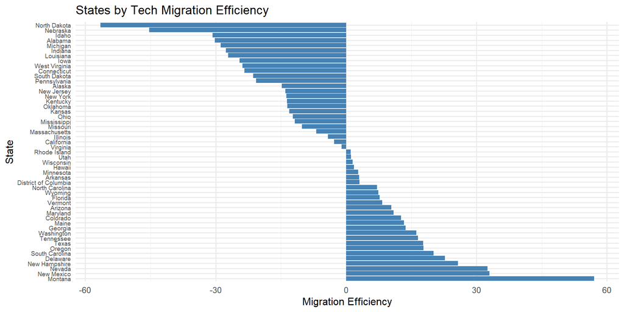

## Now Graphed

```r
states_shp2 <- states_shp %>%
  left_join(in_out_acs_tech, by = c("STATE_NAME" = "STATENAME"))

p1 <- ggplot() +
  geom_sf(data = states_shp2, aes(fill=efficiency_acs), size=0.1) +
  coord_sf(crs = "epsg:5070") +
  geom_segment(aes(x = -60, y = 60, xend = -60, yend = 60), size=0.2) +
  scale_fill_distiller(name=' ', palette='RdBu',direction=1,
                      limits=c(-60,60),
                      breaks=seq(-60,60, by =15)) +
  labs(title = "Tech Migration Efficiency All 4 Years") +
  theme(panel.grid.major = element_blank(),
        panel.grid.minor = element_blank(),
        panel.background = element_blank(),
        axis.line = element_blank(),
        axis.text.x=element_blank(),
        axis.text.y=element_blank(),
        axis.ticks=element_blank(),
        axis.title=element_blank(),
        legend.key.size =  unit(0.5, "in"),
        legend.text = element_text(size=12),
        legend.title = element_text(size=10),
        plot.title = element_text(size=20,hjust = 0.5),
        plot.subtitle = element_text(hjust = 0.5),
        plot.margin=unit(c(1, 1, 1, 1), "points"),
        strip.background = element_rect(fill='white'),
        strip.text.x = element_text(size = 10))

print(p1)
```

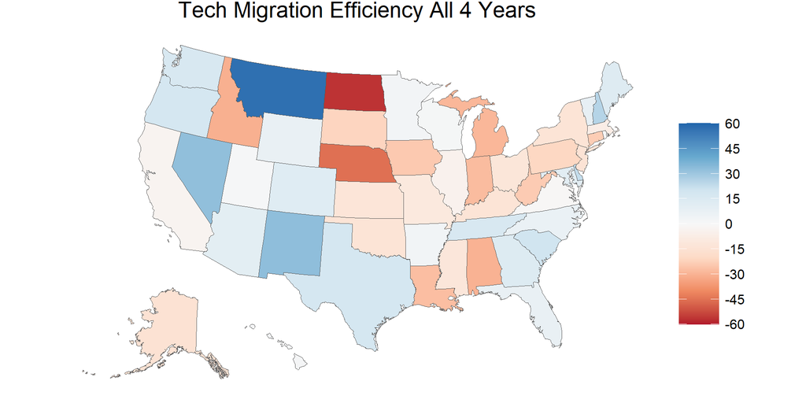

## Now Graphed by the Different Years

```r
state_flow_acs_tech_years <- tech_data %>%
  filter(mover==1) %>%
  group_by(PREV_STATENAME, STATENAME, YEAR) %>%
  summarize(flow=sum(PERWT)) %>%
  ungroup() %>%
  complete(PREV_STATENAME, STATENAME, YEAR, fill = list(flow = 0))

in_out_acs_tech_years <- state_flow_acs_tech_years %>%
  group_by(PREV_STATENAME, YEAR) %>%
  mutate(outflow_acs=sum(flow)) %>%
  group_by(STATENAME, YEAR) %>%
  mutate(inflow_acs=sum(flow)) %>%
  select(PREV_STATENAME,STATENAME, YEAR, outflow_acs, inflow_acs) %>%
  filter(PREV_STATENAME==STATENAME) %>%
  mutate(netmig_acs=inflow_acs-outflow_acs) %>%
  select(-PREV_STATENAME)


in_out_acs_tech_years <- in_out_acs_tech_years %>%
  mutate(efficiency_acs=100*(netmig_acs/(inflow_acs+outflow_acs)))
```

```r
states_shp3 <- states_shp %>%
  left_join(in_out_acs_tech_years, by = c("STATE_NAME" = "STATENAME"))

p2 <- ggplot() +
  geom_sf(data = states_shp3, aes(fill = efficiency_acs), size = 0.1) +
  coord_sf(crs = "epsg:5070") +
  scale_fill_distiller(
    name = ' ',
    palette = 'RdBu',
    direction = 1,
    limits = c(-75, 75),
    breaks = seq(-75, 75, by = 15)
  ) +
  labs(title = "Tech Migration Efficiency All 4 Years") +
  theme(
    panel.grid.major = element_blank(),
    panel.grid.minor = element_blank(),
    panel.background = element_blank(),
    axis.line = element_blank(),
    axis.text.x = element_blank(),
    axis.text.y = element_blank(),
    axis.ticks = element_blank(),
    axis.title = element_blank(),
    legend.key.size = unit(0.5, "in"),
    legend.text = element_text(size = 12),
    legend.title = element_text(size = 10),
    plot.title = element_text(size = 20, hjust = 0.5),
    strip.background = element_rect(fill = 'white'),
    strip.text.x = element_text(size = 10)
  ) +
  facet_wrap(~YEAR)

print(p2)
```

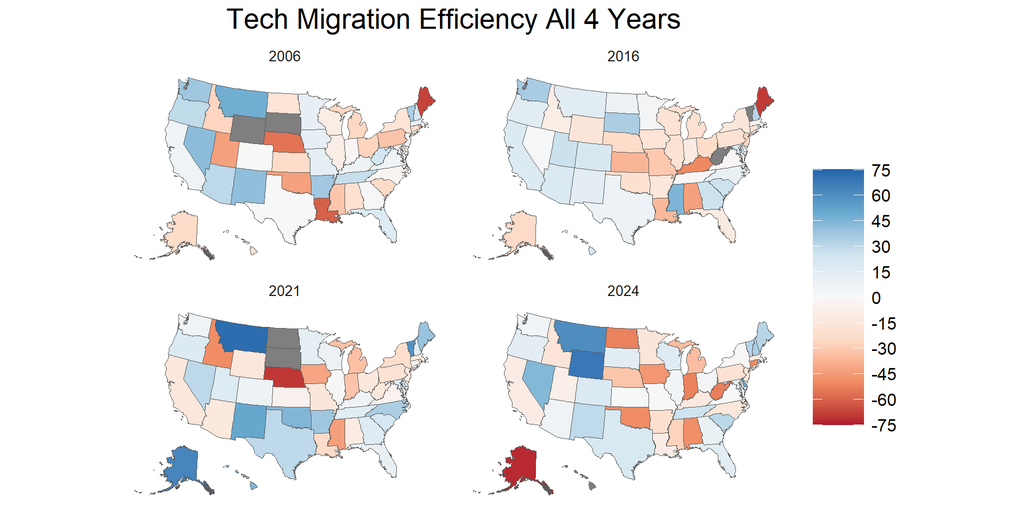

## King County has the highest Flow from California

```r
county_flow_acs_tech %>%
  arrange(desc(flow)) %>%
  slice_head(n = 5) %>%      # first 5 rows
  gt()
```

| PREV_STATENAME | STATENAME | COUNTYFIP | flow |
| --- | --- | --- | --- |
| California | Washington | 033 | 8791 |
| California | Colorado | 000 | 5602 |
| Virginia | District of Columbia | 001 | 4722 |
| California | Texas | 453 | 4423 |
| Massachusetts | New Hampshire | 000 | 3917 |

## Tech focus Migration Efficiency vs General Migration Efficiency

```r
tech_val <- in_out_acs_tech %>%
  filter(STATENAME == "Washington") %>%
  pull(efficiency_acs)

state_val <- in_out_acs_state %>%
  filter(STATENAME == "Washington") %>%
  pull(efficiency_acs)

difference <- tech_val - state_val
print("Tech Focused Migration has a higher Migration Efficiency by: ")
```

```
[1] "Tech Focused Migration has a higher Migration Efficiency by: "
```

```r
print(difference)
```

```
[1] 11.772
```

## Conclusion

- Will use IRS Data to to further county by county migration
- It is difficult to define what a tech job is
- Washington has had a decent amount of tech migration over the years